# Part 1 - Statistical tests for comparing different groups before imputing missing values

2024-03-14

Importing raw data

Check the normality of data

```r
# Filter data for patients who are alive or diseased
alive_data <- mimic_iv[mimic_iv$mortality == 0, ]
deceased_data <- mimic_iv[mimic_iv$mortality == 1, ]
```

Histogram and Q-Q plot of all the numerical continuous variables

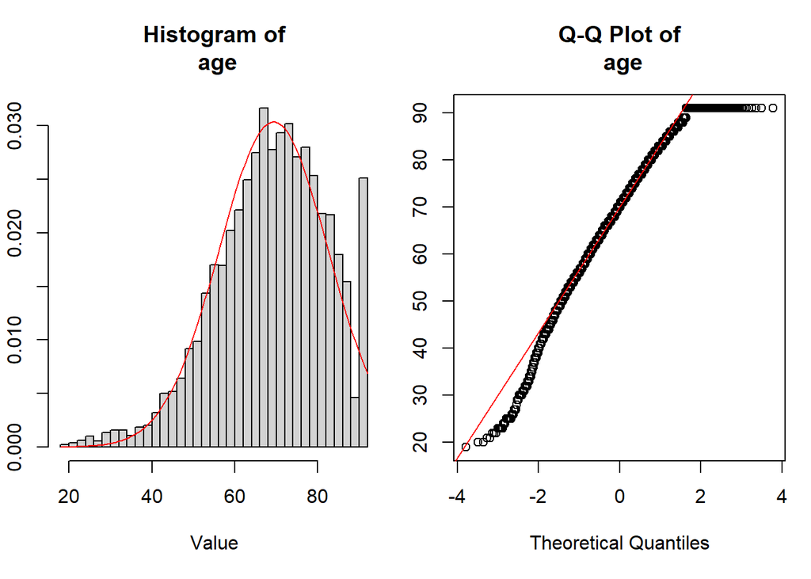

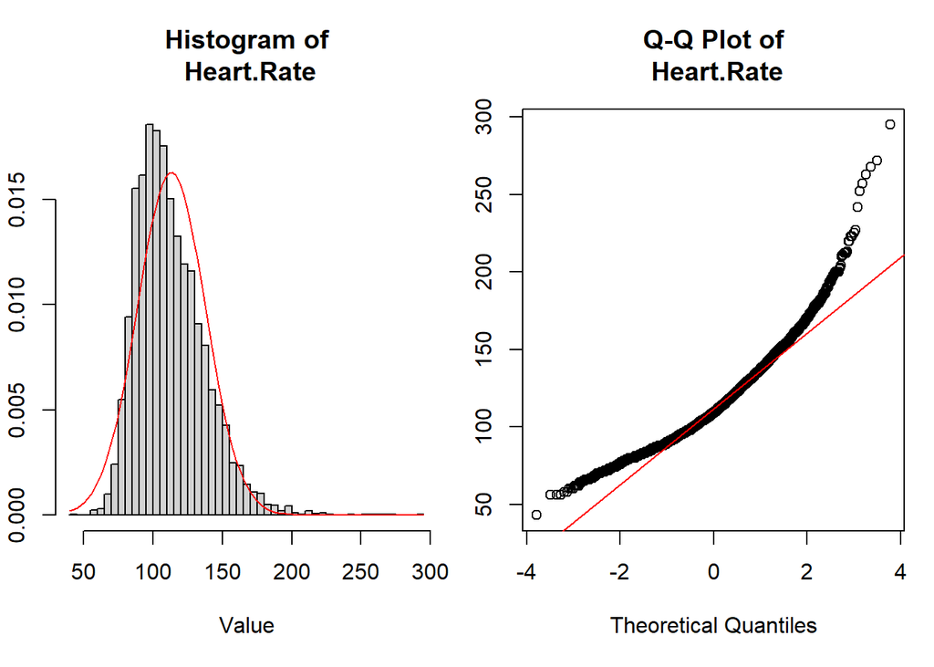

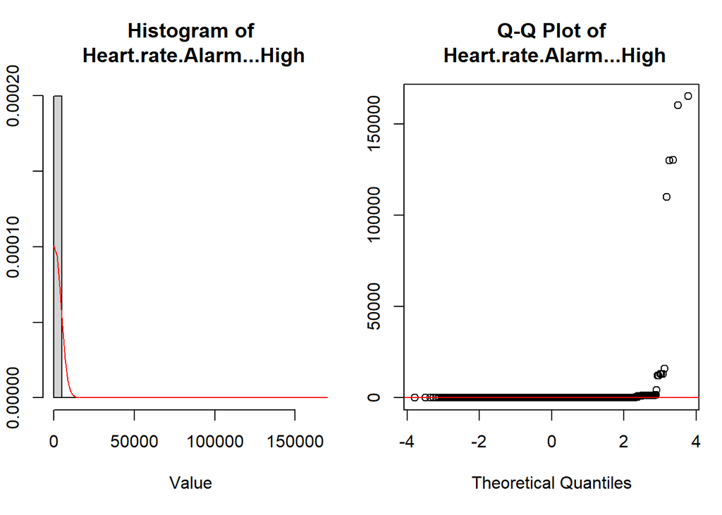

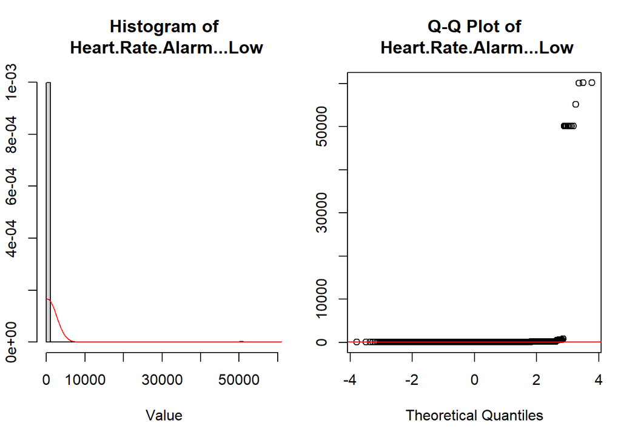

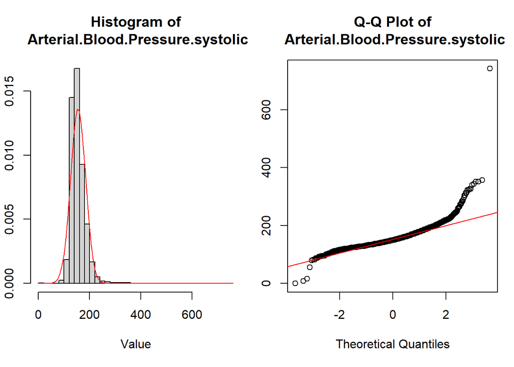

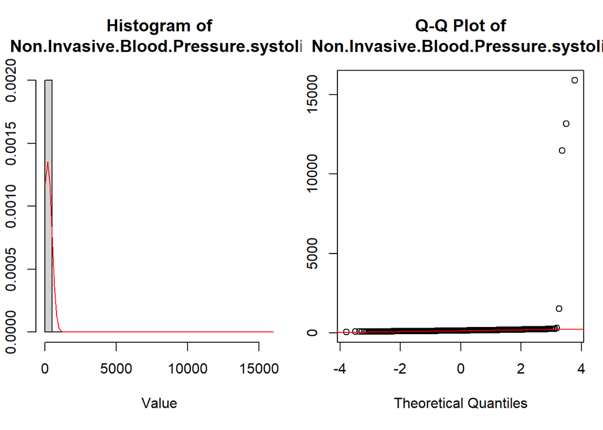

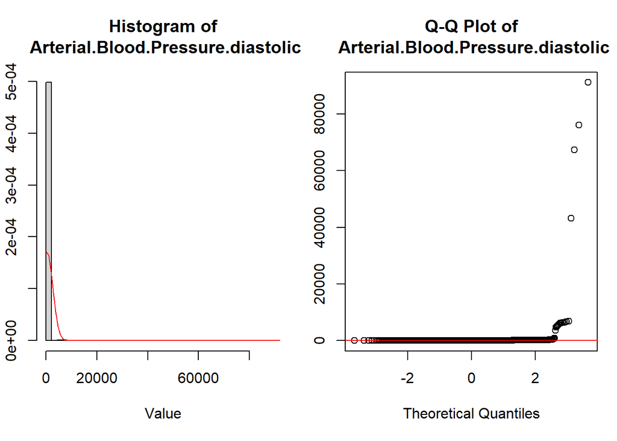

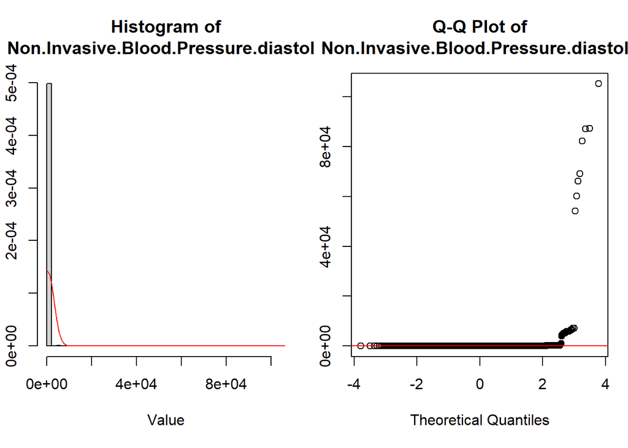

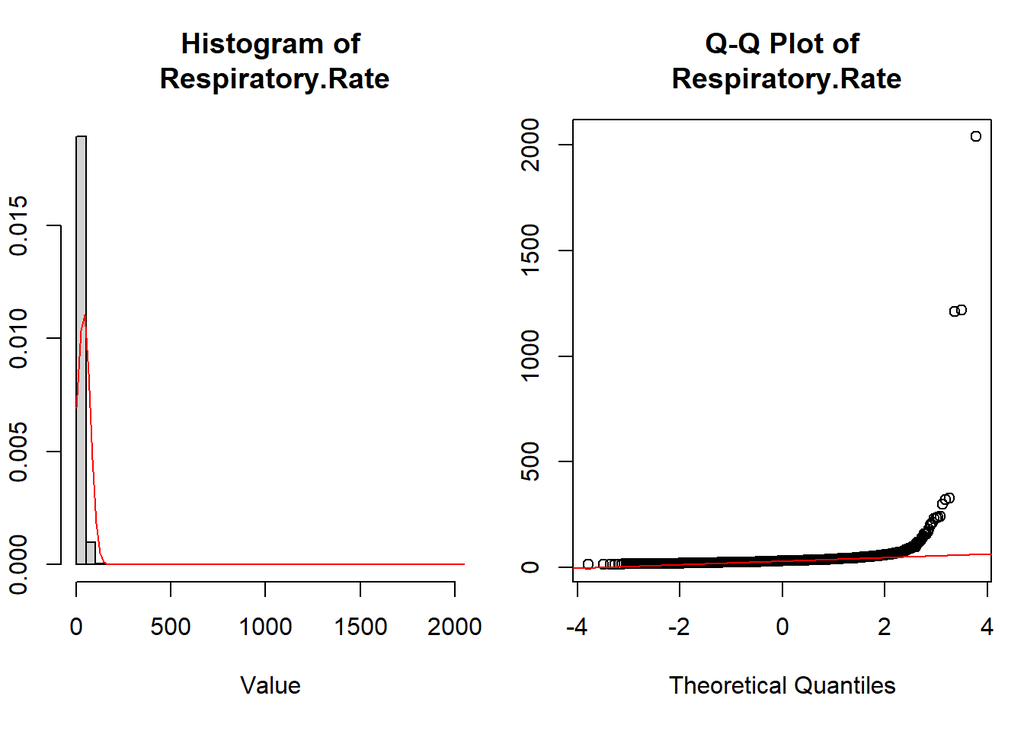

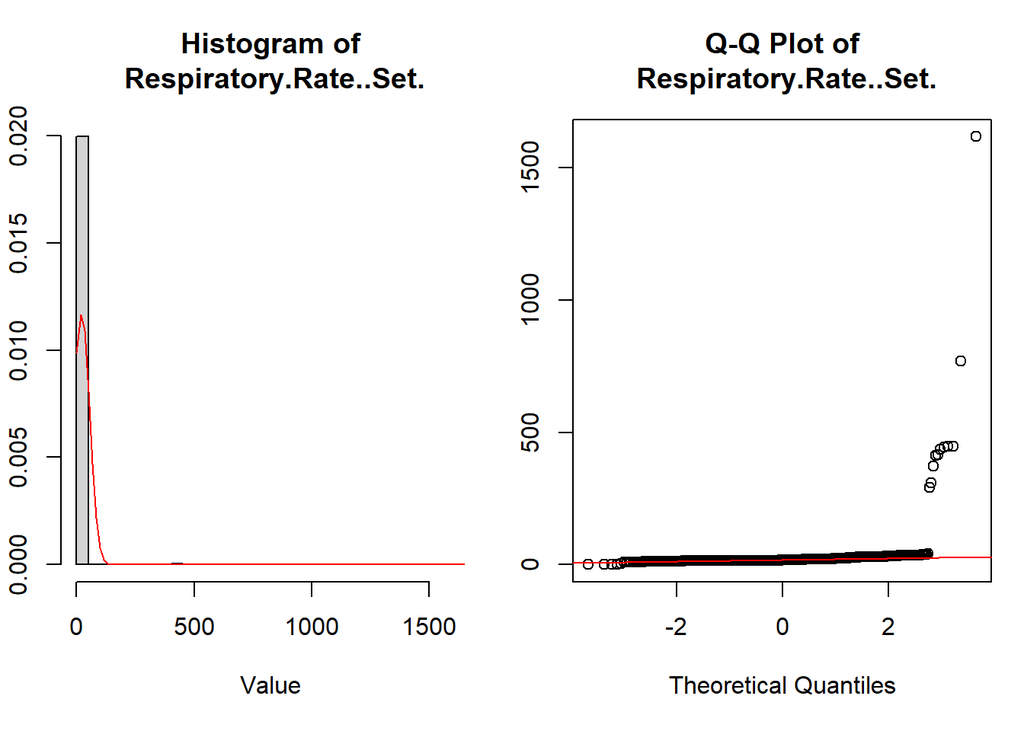

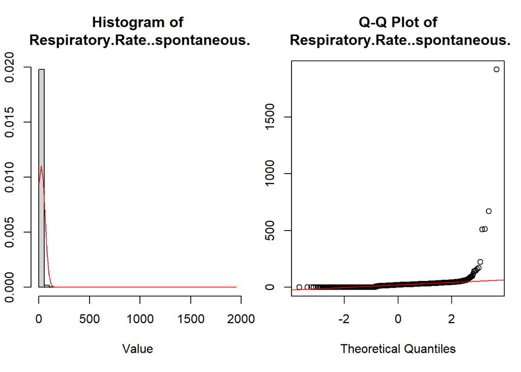

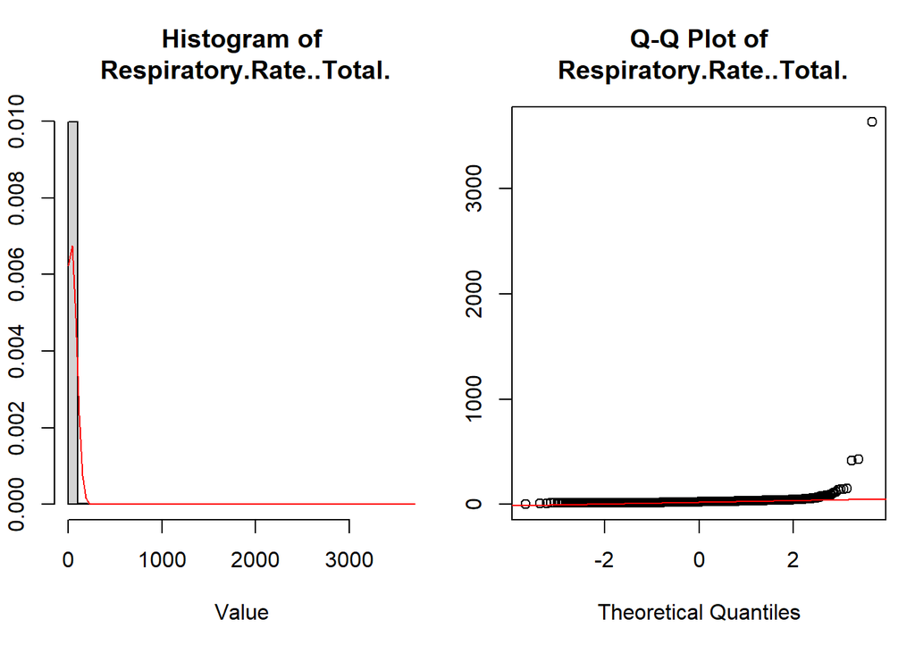

[18 more figures not shown]

```r
# Loop through each variable
for (var in c(
  "age",
  "Heart.Rate",
  "Heart.rate.Alarm...High",
  "Heart.Rate.Alarm...Low",
  "Arterial.Blood.Pressure.systolic",
  "Non.Invasive.Blood.Pressure.systolic",
  "Arterial.Blood.Pressure.diastolic",
  "Non.Invasive.Blood.Pressure.diastolic",
  "Respiratory.Rate",
  "Respiratory.Rate..Set.",
  "Respiratory.Rate..spontaneous.",
  "Respiratory.Rate..Total.",
  "SpO2.Desat.Limit",
  "INR",
  "Prothrombin.time",
  "Anion.gap",
  "Creatinine..serum.",
  "Temperature",
  "Potassium..Whole.Blood.2",
  "Potassium..whole.blood.",
  "Sodium..whole.blood.",
  "Sodium..Whole.Blood",
  "Chloride..Whole.Blood",
  "Chloride..whole.blood.",
  "Bicarbonate",
  "Glucose..whole.blood.",
  "Hemoglobin",
  "Hemoglobin.2",
  "Hematocrit",
  "Platelet.Count"
)) {
  # Set up the plotting area
  par(mfrow = c(1, 2), mar = c(5,2,4,1) + 0.1)

  # Plot a histogram for the current variable
  hist(mimic_iv[[var]], freq = FALSE, main = paste("Histogram of\n", var), xlab = "Value", ylab = "Density", breaks = 50)

  # Add a normal distribution curve
  curve(dnorm(x, mean = mean(mimic_iv[[var]], na.rm = TRUE), sd = sd(mimic_iv[[var]], na.rm = TRUE)),
        add = TRUE, col = "red")

  # Create a Q-Q plot for the current variable
  qqnorm(mimic_iv[[var]], main = paste("Q-Q Plot of\n", var))
  qqline(mimic_iv[[var]], col = "red")
}
```

```r
# Reset the plotting area
par(mfrow = c(1, 1))
```

List of column names want to perform t-tests or Mann-Whitney U test

```r
normaly_distributed_col <- c("Chloride..Whole.Blood","Bicarbonate","Hemoglobin.2","Hematocrit")

non_normaly_distributed_col <- c(
  "age", "Heart.Rate", "Heart.rate.Alarm...High", "Heart.Rate.Alarm...Low",
  "Arterial.Blood.Pressure.systolic", "Non.Invasive.Blood.Pressure.systolic",
  "Arterial.Blood.Pressure.diastolic", "Non.Invasive.Blood.Pressure.diastolic",
  "Respiratory.Rate", "Respiratory.Rate..Set.", "Respiratory.Rate..spontaneous.",
  "Respiratory.Rate..Total.", "SpO2.Desat.Limit", "INR", "Prothrombin.time",
  "Anion.gap", "Creatinine..serum.", "Temperature", "Potassium..Whole.Blood.2",
  "Potassium..whole.blood.", "Sodium..whole.blood.", "Sodium..Whole.Blood",
  "Chloride..whole.blood.","Glucose..whole.blood.", "Hemoglobin", "Platelet.Count"
)
```

We performed t-test for the normally distributed data

```r
# Create an empty data frame to store the results
results_df <- data.frame(variable = character(), p_value = numeric(), stringsAsFactors = FALSE)

# Loop over each column
for (col in normaly_distributed_col) {
  # Perform t-test
  t_test_result <- t.test(alive_data[[col]], deceased_data[[col]])

  # Store the results in the data frame
  results_df <- rbind(results_df, data.frame(variable = col, p_value = t_test_result$p.value))
}

# Print the results data frame
print(results_df)
```

```
##                variable      p_value
## 1 Chloride..Whole.Blood 3.965960e-01
## 2           Bicarbonate 8.247869e-02
## 3          Hemoglobin.2 1.954057e-07
## 4            Hematocrit 8.043018e-03
```

```r
# Sort the results by p-value
results_df <- results_df[order(results_df$p_value), ]

# Print the results as a table
print(knitr::kable(results_df))
```

```
##
##
## |   |variable              |   p_value|
## |:--|:---------------------|---------:|
## |3  |Hemoglobin.2          | 0.0000002|
## |4  |Hematocrit            | 0.0080430|
## |2  |Bicarbonate           | 0.0824787|
## |1  |Chloride..Whole.Blood | 0.3965960|
```

Based on the results of T-test:

- **Significantly Different Variables:** Hemoglobin.2 and Hematocrit have very low p-values (0.0000002 and 0.0080430, respectively), suggesting a significant difference in these variables between the groups. These variables are likely to be important predictors or indicators of the outcome being studied.
- **Non-Significant Variables:** Bicarbonate and Chloride..Whole.Blood have p-values of 0.0824787 and 0.3965960, respectively, which are higher than the typical significance threshold of 0.05. This suggests that there may not be significant differences in these variables between the groups.

We performed Mann-Whitney U test for the skewed data.

```r
# Create an empty data frame to store the results
results_df1 <- data.frame(variable = character(), p_value = numeric(), stringsAsFactors = FALSE)

# Loop over each column
for (col in non_normaly_distributed_col) {
  # Perform Mann-Whitney U test
  mwu_test_result <- wilcox.test(alive_data[[col]], deceased_data[[col]])

  # Store the results in the data frame
  results_df1 <- rbind(results_df1, data.frame(variable = col, p_value = mwu_test_result$p.value))
}

# Print the results data frame
print(results_df1)
```

```
##                                 variable       p_value
## 1                                    age  2.928201e-24
## 2                             Heart.Rate 2.288188e-103
## 3                Heart.rate.Alarm...High  1.850004e-50
## 4                 Heart.Rate.Alarm...Low  5.839689e-03
## 5       Arterial.Blood.Pressure.systolic  4.295483e-09
## 6   Non.Invasive.Blood.Pressure.systolic  2.008735e-12
## 7      Arterial.Blood.Pressure.diastolic  1.606535e-09
## 8  Non.Invasive.Blood.Pressure.diastolic  2.039086e-15
## 9                       Respiratory.Rate  6.275053e-77
## 10                Respiratory.Rate..Set.  4.224748e-83
## 11        Respiratory.Rate..spontaneous.  1.374629e-32
## 12              Respiratory.Rate..Total. 1.021804e-109
## 13                      SpO2.Desat.Limit  7.798524e-34
## 14                                   INR  2.787749e-64
## 15                      Prothrombin.time  3.137550e-65
## 16                             Anion.gap 2.165015e-157
## 17                    Creatinine..serum. 1.247040e-109
## 18                           Temperature  1.096741e-04
## 19              Potassium..Whole.Blood.2  3.111690e-01
## 20               Potassium..whole.blood.  1.132994e-02
## 21                  Sodium..whole.blood.  1.185185e-01
## 22                   Sodium..Whole.Blood  2.662506e-08
## 23                Chloride..whole.blood.  1.661543e-01
## 24                 Glucose..whole.blood.  4.927475e-05
## 25                            Hemoglobin  1.421680e-15
## 26                        Platelet.Count  1.566960e-02
```

```r
# Sort the results by p-value
results_df1 <- results_df1[order(results_df1$p_value), ]

# Print the results as a table
print(knitr::kable(results_df1))
```

```
##
##
## |   |variable                              |   p_value|
## |:--|:-------------------------------------|---------:|
## |16 |Anion.gap                             | 0.0000000|
## |12 |Respiratory.Rate..Total.              | 0.0000000|
## |17 |Creatinine..serum.                    | 0.0000000|
## |2  |Heart.Rate                            | 0.0000000|
## |10 |Respiratory.Rate..Set.                | 0.0000000|
## |9  |Respiratory.Rate                      | 0.0000000|
## |15 |Prothrombin.time                      | 0.0000000|
## |14 |INR                                   | 0.0000000|
## |3  |Heart.rate.Alarm...High               | 0.0000000|
## |13 |SpO2.Desat.Limit                      | 0.0000000|
## |11 |Respiratory.Rate..spontaneous.        | 0.0000000|
## |1  |age                                   | 0.0000000|
## |25 |Hemoglobin                            | 0.0000000|
## |8  |Non.Invasive.Blood.Pressure.diastolic | 0.0000000|
## |6  |Non.Invasive.Blood.Pressure.systolic  | 0.0000000|
## |7  |Arterial.Blood.Pressure.diastolic     | 0.0000000|
## |5  |Arterial.Blood.Pressure.systolic      | 0.0000000|
## |22 |Sodium..Whole.Blood                   | 0.0000000|
## |24 |Glucose..whole.blood.                 | 0.0000493|
## |18 |Temperature                           | 0.0001097|
## |4  |Heart.Rate.Alarm...Low                | 0.0058397|
## |20 |Potassium..whole.blood.               | 0.0113299|
## |26 |Platelet.Count                        | 0.0156696|
## |21 |Sodium..whole.blood.                  | 0.1185185|
## |23 |Chloride..whole.blood.                | 0.1661543|
## |19 |Potassium..Whole.Blood.2              | 0.3111690|
```

# Cleaning Data

Calculate missing value count percentage column(variable) wise

```r
# Calculate missing value count and percentage for each column
missing_values <- colSums(is.na(mimic_iv))
missing_percentage <- (missing_values / nrow(mimic_iv)) * 100

# Create a data frame to store the results
missing_data <- data.frame(missing_count = missing_values, missing_percentage = missing_percentage)

# Filter to include only columns with missing data
missing_data_filtered <- missing_data[missing_data$missing_count > 0, ]

# Sort the data frame by missing_percentage in descending order
missing_data_sorted <- missing_data_filtered[order(-missing_data_filtered$missing_percentage), ]

# Print the results in a table format
knitr::kable(missing_data_sorted, caption = "Missing Value Summary")
```

Missing Value Summary

|  | missing_count | missing_percentage |
| --- | --- | --- |
| Temperature | 3840 | 60.2164027 |
| Chloride..whole.blood. | 3569 | 55.9667555 |
| Sodium..whole.blood. | 3362 | 52.7207151 |
| Glucose..whole.blood. | 2953 | 46.3070409 |
| Potassium..whole.blood. | 2802 | 43.9391563 |
| Arterial.Blood.Pressure.systolic | 2478 | 38.8583974 |
| Arterial.Blood.Pressure.diastolic | 2477 | 38.8427160 |
| Respiratory.Rate..Set. | 2470 | 38.7329465 |
| Hemoglobin | 2357 | 36.9609534 |
| Respiratory.Rate..spontaneous. | 2300 | 36.0671162 |
| Respiratory.Rate..Total. | 2286 | 35.8475772 |
| Chloride..Whole.Blood | 2267 | 35.5496315 |
| Sodium..Whole.Blood | 2121 | 33.2601537 |
| Potassium..Whole.Blood.2 | 1441 | 22.5968324 |
| INR | 236 | 3.7007997 |
| Prothrombin.time | 236 | 3.7007997 |
| Non.Invasive.Blood.Pressure.systolic | 45 | 0.7056610 |
| Non.Invasive.Blood.Pressure.diastolic | 45 | 0.7056610 |
| Anion.gap | 17 | 0.2665830 |
| Creatinine..serum. | 14 | 0.2195390 |
| SpO2.Desat.Limit | 13 | 0.2038576 |
| Heart.Rate.Alarm…Low | 4 | 0.0627254 |
| Heart.rate.Alarm…High | 3 | 0.0470441 |
| Bicarbonate | 3 | 0.0470441 |
| Respiratory.Rate | 2 | 0.0313627 |

# Combining Columns

**Arterial.Blood.Pressure.systolic and Non.Invasive.Blood.Pressure.systolic**

1. Arterial Blood Pressure (ABP) Systolic: obtained using an more invasive and potentially more accurate.
2. Non-Invasive Blood Pressure (NIBP) Systolic: obtained using a non-invasive method and more convenient but may be less accurate compared to ABP.

```r
# Check correlation between the two variables
correlation <- cor(mimic_iv$Arterial.Blood.Pressure.systolic, mimic_iv$Non.Invasive.Blood.Pressure.systolic, use = "complete.obs")
```

With a correlation of approximately 0.08325, the Arterial.Blood.Pressure.systolic and Non.Invasive.Blood.Pressure.systolic variables have a very weak positive correlation. Which means they are not strongly related, and consolidating them might not provide much benefit in terms of improving the data quality. But these variables are to measure systolic blood pressure using different methods, so we are gonna create a new variable, averaging the two variables.

```r
# Calculate the average of the two blood pressure variables
mimic_iv$AvgBloodPressureSystolic <- rowMeans(mimic_iv[, c("Arterial.Blood.Pressure.systolic", "Non.Invasive.Blood.Pressure.systolic")], na.rm = TRUE)

# Check if there are any remaining missing values
any(is.na(mimic_iv$AvgBloodPressureSystolic))
```

```
## [1] TRUE
```

This code calculates the row-wise mean of the two blood pressure variables and creates a new variable AvgBloodPressureSystolic in the dataset.

**Arterial.Blood.Pressure.diastolic and Non.Invasive.Blood.Pressure.diastolic**

1. Arterial Blood Pressure (ABP) Diastolic: more invasive but potentially more accurate
2. Non-Invasive Blood Pressure (NIBP) Diastolic: less invasive but may be less accurate in certain situations.

```r
# Check correlation between the two variables
correlation <- cor(mimic_iv$Arterial.Blood.Pressure.diastolic, mimic_iv$Non.Invasive.Blood.Pressure.diastolic, use = "complete.obs")
```

With a correlation of approximately -0.0009740, the Arterial.Blood.Pressure.diastolic and Non.Invasive.Blood.Pressure.diastolic variables have a very weak negative correlation. This suggests that the two variables are not correlated or are very weakly related. In this case, similar to the systolic blood pressure variables, consolidating these variables might not provide much benefit in terms of improving data quality or reducing redundancy. But these variables are to measure diastolic blood pressure using different methods, so we are gonna create a new variable, averaging the two variables.

```r
# Calculate the average of the two blood pressure variables
mimic_iv$AvgBloodPressureDiastolic <- rowMeans(mimic_iv[, c("Arterial.Blood.Pressure.diastolic", "Non.Invasive.Blood.Pressure.diastolic")], na.rm = TRUE)

# Check if there are any remaining missing values
any(is.na(mimic_iv$AvgBloodPressureDiastolic))
```

```
## [1] TRUE
```

This code calculates the row-wise mean of the two blood pressure variables and creates a new variable AvgBloodPressureDiastolic in the dataset.

**Combining Respiratory Rate variables**

1. Respiratory.Rate : general measurement of breathes per minute
2. Respiratory.Rate..Set : fixed or set respiratory rate. During mechanical ventilation
3. Respiratory.Rate..spontaneous : natural respiratory rate. Without any external intervention to control the breath
4. Respiratory.Rate..Total : cumulative respiratory rate over a period

```r
correlation_matrix <- cor(mimic_iv[, c("Respiratory.Rate..Set.", "Respiratory.Rate..spontaneous.", "Respiratory.Rate..Total.", "Respiratory.Rate")], use = "complete.obs")
knitr::kable(correlation_matrix, caption = "Correlation matrix of Respiratory rate")
```

Correlation matrix of Respiratory rate

|  | Respiratory.Rate..Set. | Respiratory.Rate..spontaneous. | Respiratory.Rate..Total. | Respiratory.Rate |
| --- | --- | --- | --- | --- |
| Respiratory.Rate..Set. | 1.0000000 | 0.0262055 | 0.0190371 | 0.0098992 |
| Respiratory.Rate..spontaneous. | 0.0262055 | 1.0000000 | 0.0511169 | 0.0352666 |
| Respiratory.Rate..Total. | 0.0190371 | 0.0511169 | 1.0000000 | 0.0145945 |
| Respiratory.Rate | 0.0098992 | 0.0352666 | 0.0145945 | 1.0000000 |

Even though they are not strongly correlated, we can still consolidate them into a one variable, because all of these variables are different ways of measuring or recording same respiratory rate.

```r
# Create a new variable for consolidated respiratory rate
mimic_iv$ConsolidatedRespiratoryRate <- rowMeans(mimic_iv[, c("Respiratory.Rate..Set.", "Respiratory.Rate..spontaneous.", "Respiratory.Rate..Total.", "Respiratory.Rate")], na.rm = TRUE)

# Check if there are any remaining missing values
any(is.na(mimic_iv$ConsolidatedRespiratoryRate))
```

```
## [1] FALSE
```

This code calculates the row-wise mean of the four respiratory rate variables, creating a new variable ConsolidatedRespiratoryRate.

**Consolidate and average following duplicated/repeated variables:**

1. Potassium..Whole.Blood.2 + Potassium..whole.blood.
2. Sodium..whole.blood. + Sodium..Whole.Blood
3. Chloride..Whole.Blood + Chloride..whole.blood.
4. Hemoglobin + Hemoglobin.2

```r
# Create new variables for consolidated and averaged values
mimic_iv$AvgPotassium <- rowMeans(mimic_iv[, c("Potassium..Whole.Blood.2", "Potassium..whole.blood.")], na.rm = TRUE)
mimic_iv$AvgSodium <- rowMeans(mimic_iv[, c("Sodium..whole.blood.", "Sodium..Whole.Blood")], na.rm = TRUE)
mimic_iv$AvgChloride <- rowMeans(mimic_iv[, c("Chloride..Whole.Blood", "Chloride..whole.blood.")], na.rm = TRUE)
mimic_iv$AvgHemoglobin <- rowMeans(mimic_iv[, c("Hemoglobin", "Hemoglobin.2")], na.rm = TRUE)

# Check if there are any remaining missing values
any(is.na(mimic_iv$AvgPotassium)) || any(is.na(mimic_iv$AvgSodium)) || any(is.na(mimic_iv$AvgChloride)) || any(is.na(mimic_iv$AvgHemoglobin))
```

```
## [1] TRUE
```

Remove the columns

```r
columns_to_remove <- c("Arterial.Blood.Pressure.systolic", "Non.Invasive.Blood.Pressure.systolic", "Arterial.Blood.Pressure.diastolic", "Non.Invasive.Blood.Pressure.diastolic", "Respiratory.Rate..Set.", "Respiratory.Rate..spontaneous.", "Respiratory.Rate..Total.", "Respiratory.Rate", "Potassium..Whole.Blood.2", "Potassium..whole.blood.", "Sodium..whole.blood.", "Sodium..Whole.Blood", "Chloride..Whole.Blood", "Chloride..whole.blood.", "Hemoglobin", "Hemoglobin.2")

# Create a new data set without the columns to remove
mimic_iv_clean <- mimic_iv[, !(names(mimic_iv) %in% columns_to_remove)]
```

Calculate again the missing value percentages

```r
# Calculate missing value count and percentage for each column
missing_values <- colSums(is.na(mimic_iv_clean))
missing_percentage <- (missing_values / nrow(mimic_iv_clean)) * 100

# Create a data frame to store the results
missing_data <- data.frame(missing_count = missing_values, missing_percentage = missing_percentage)

# Filter to include only columns with missing data
missing_data_filtered <- missing_data[missing_data$missing_count > 0, ]

# Sort the data frame by missing_percentage in descending order
missing_data_sorted <- missing_data_filtered[order(-missing_data_filtered$missing_percentage), ]

# Print the results in a table format
knitr::kable(missing_data_sorted, caption = "Missing Value Summary After Combining Features")
```

Missing Value Summary After Combining Features

|  | missing_count | missing_percentage |
| --- | --- | --- |
| Temperature | 3840 | 60.2164027 |
| Glucose..whole.blood. | 2953 | 46.3070409 |
| AvgChloride | 2265 | 35.5182688 |
| AvgSodium | 2119 | 33.2287910 |
| AvgPotassium | 1441 | 22.5968324 |
| INR | 236 | 3.7007997 |
| Prothrombin.time | 236 | 3.7007997 |
| Anion.gap | 17 | 0.2665830 |
| Creatinine..serum. | 14 | 0.2195390 |
| SpO2.Desat.Limit | 13 | 0.2038576 |
| Heart.Rate.Alarm…Low | 4 | 0.0627254 |
| Heart.rate.Alarm…High | 3 | 0.0470441 |
| Bicarbonate | 3 | 0.0470441 |
| AvgBloodPressureSystolic | 2 | 0.0313627 |
| AvgBloodPressureDiastolic | 2 | 0.0313627 |

After combining some variables we can see these differences in the missing value percentages:

```r
library(kableExtra)
# Create a data frame with the before and after values
table_before <- data.frame(
  Before_Missing_Count = c(2478, 45, 2477, 45, 2470, 2300, 2286, 2, 3569, 2267, 3362, 2121, 2802, 1441, 2357, 0),
  row.names = c("Arterial.Blood.Pressure.systolic", "Non.Invasive.Blood.Pressure.systolic",
                "Arterial.Blood.Pressure.diastolic", "Non.Invasive.Blood.Pressure.diastolic",
                "Respiratory.Rate..Set.", "Respiratory.Rate..spontaneous.", "Respiratory.Rate..Total.",
                "Respiratory.Rate", "Chloride..whole.blood.", "Chloride..Whole.Blood",                                 "Sodium..whole.blood","Sodium..Whole.Blood", "Potassium..whole.blood.",                                "Potassium..Whole.Blood.2","Hemoglobin", "Hemoglobin.2")
)

table_after <- data.frame(
  After_Missing_Count = c(2, 2, 0, 2265, 2119, 1441, 0),
  row.names = c("AvgBloodPressureSystolic", "AvgBloodPressureDiastolic", "ConsolidatedRespiratoryRate",                 "AvgChloride", "AvgSodium", "AvgPotassium", "AvgHemoglobin")
)

# Print the table using kable
knitr::kable(table_before, caption = "Before combining variables")
```

Before combining variables

|  | Before_Missing_Count |
| --- | --- |
| Arterial.Blood.Pressure.systolic | 2478 |
| Non.Invasive.Blood.Pressure.systolic | 45 |
| Arterial.Blood.Pressure.diastolic | 2477 |
| Non.Invasive.Blood.Pressure.diastolic | 45 |
| Respiratory.Rate..Set. | 2470 |
| Respiratory.Rate..spontaneous. | 2300 |
| Respiratory.Rate..Total. | 2286 |
| Respiratory.Rate | 2 |
| Chloride..whole.blood. | 3569 |
| Chloride..Whole.Blood | 2267 |
| Sodium..whole.blood | 3362 |
| Sodium..Whole.Blood | 2121 |
| Potassium..whole.blood. | 2802 |
| Potassium..Whole.Blood.2 | 1441 |
| Hemoglobin | 2357 |
| Hemoglobin.2 | 0 |

```r
knitr::kable(table_after, caption = "After combining variables")
```

After combining variables

|  | After_Missing_Count |
| --- | --- |
| AvgBloodPressureSystolic | 2 |
| AvgBloodPressureDiastolic | 2 |
| ConsolidatedRespiratoryRate | 0 |
| AvgChloride | 2265 |
| AvgSodium | 2119 |
| AvgPotassium | 1441 |
| AvgHemoglobin | 0 |

For handling missing values in the mimic_iv_clean data set for variables related to lab tests and vital signs, we are doing the statistical test before imputation:

**Missingness by group:** Impute missing values based on the similar cases. For that we are gonna calculate the missing values for each variable by age, gender and ethnicity. And going to use only the variables with highest percentage of missing values.

Why did we consider Age, Gender, Ethnicity:

1. Age: Age can be an important factor in healthcare data analysis as different age groups may have different patterns of missingness. For example, certain medical tests or measurements may be more common or relevant in specific age groups, leading to different rates of missing data.
2. Gender: Gender can also play a role in healthcare and medical data. Some conditions or tests may be more prevalent or important for one gender than the other, leading to differences in missing data patterns.
3. Ethnicity: Ethnicity can be associated with various health factors and medical conditions, which could influence the presence or absence of certain variables in the data set.

```r
# Load necessary libraries
library(dplyr)
```

```r
library(tidyr)
library(ggplot2)

# List of variables to analyze
variables <- c("Temperature", "Glucose..whole.blood.", "AvgChloride", "AvgSodium", "AvgPotassium")
```

**Missingness by Age.Group**

```
##
## Summary table for Temperature
## # A tibble: 4 × 4
##   Age.Group min_missing max_missing mean_missing
##   <chr>           <dbl>       <dbl>        <dbl>
## 1 19-35           0.535       0.535        0.535
## 2 36-50           0.603       0.603        0.603
## 3 51-65           0.584       0.584        0.584
## 4 66-100          0.612       0.612        0.612
## [1] "Chi-square test result for Temperature"
##
##  Pearson's Chi-squared test
##
## data:  chi_sq_variable
## X-squared = 5.9139, df = 3, p-value = 0.1159
```

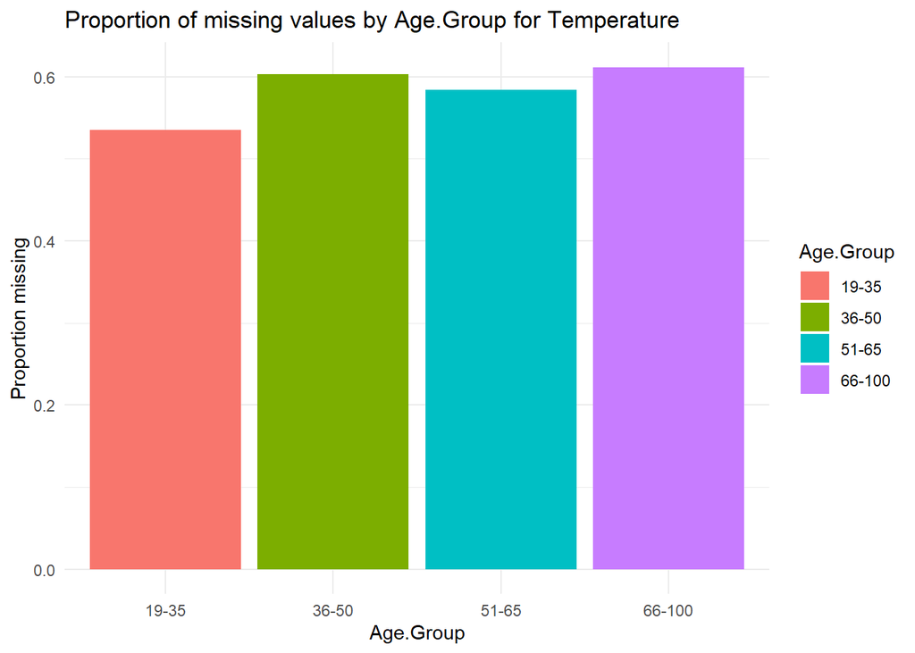

```
##
## Summary table for Glucose..whole.blood.
## # A tibble: 4 × 4
##   Age.Group min_missing max_missing mean_missing
##   <chr>           <dbl>       <dbl>        <dbl>
## 1 19-35           0.545       0.545        0.545
## 2 36-50           0.386       0.386        0.386
## 3 51-65           0.370       0.370        0.370
## 4 66-100          0.509       0.509        0.509
## [1] "Chi-square test result for Glucose..whole.blood."
##
##  Pearson's Chi-squared test
##
## data:  chi_sq_variable
## X-squared = 108.9, df = 3, p-value < 2.2e-16
```

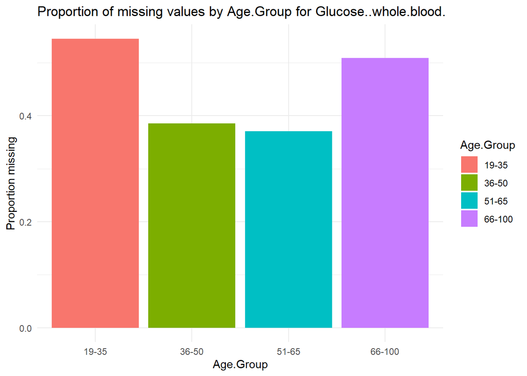

```
##
## Summary table for AvgChloride
## # A tibble: 4 × 4
##   Age.Group min_missing max_missing mean_missing
##   <chr>           <dbl>       <dbl>        <dbl>
## 1 19-35           0.434       0.434        0.434
## 2 36-50           0.285       0.285        0.285
## 3 51-65           0.279       0.279        0.279
## 4 66-100          0.393       0.393        0.393
## [1] "Chi-square test result for AvgChloride"
##
##  Pearson's Chi-squared test
##
## data:  chi_sq_variable
## X-squared = 82.618, df = 3, p-value < 2.2e-16
```

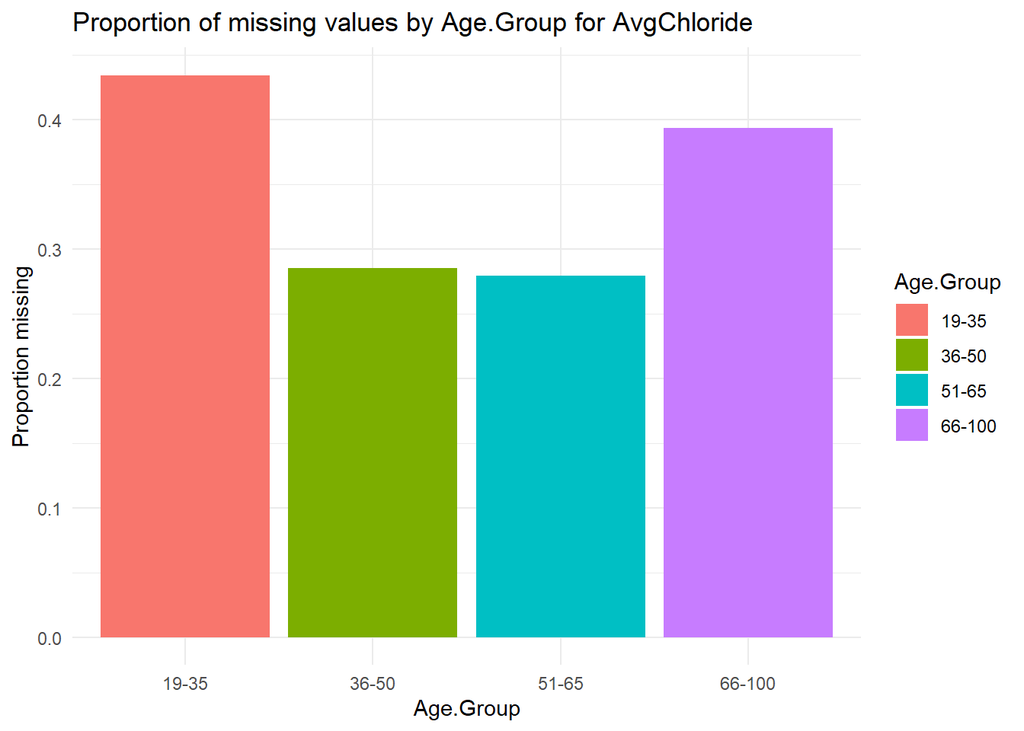

```
##
## Summary table for AvgSodium
## # A tibble: 4 × 4
##   Age.Group min_missing max_missing mean_missing
##   <chr>           <dbl>       <dbl>        <dbl>
## 1 19-35           0.404       0.404        0.404
## 2 36-50           0.266       0.266        0.266
## 3 51-65           0.260       0.260        0.260
## 4 66-100          0.368       0.368        0.368
## [1] "Chi-square test result for AvgSodium"
##
##  Pearson's Chi-squared test
##
## data:  chi_sq_variable
## X-squared = 75.938, df = 3, p-value = 2.281e-16
```

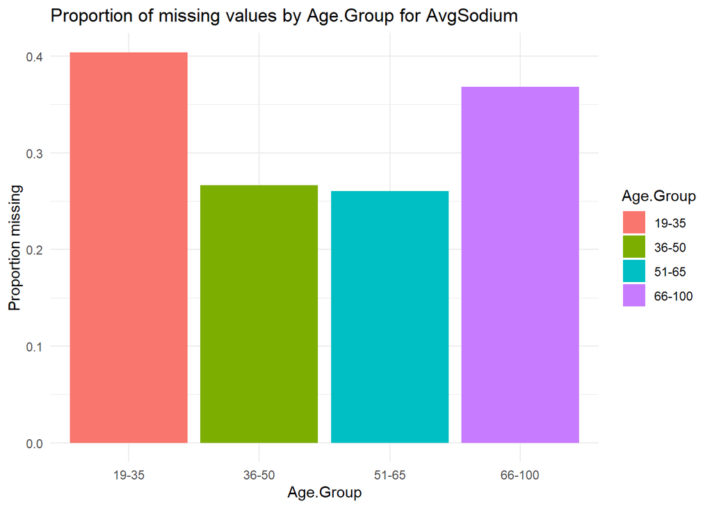

```
##
## Summary table for AvgPotassium
## # A tibble: 4 × 4
##   Age.Group min_missing max_missing mean_missing
##   <chr>           <dbl>       <dbl>        <dbl>
## 1 19-35           0.273       0.273        0.273
## 2 36-50           0.171       0.171        0.171
## 3 51-65           0.175       0.175        0.175
## 4 66-100          0.253       0.253        0.253
## [1] "Chi-square test result for AvgPotassium"
##
##  Pearson's Chi-squared test
##
## data:  chi_sq_variable
## X-squared = 52.005, df = 3, p-value = 2.988e-11
```

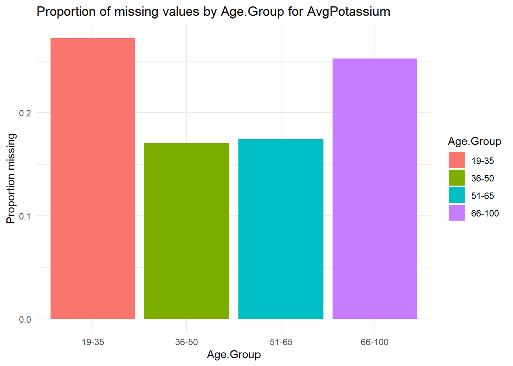

```r
# Loop through each variable
for (variable in variables) {
  # Calculate the proportion of missing values by Age.Group
  missing_summary_variable <- mimic_iv_clean %>%
    group_by(Age.Group) %>%
    summarise(prop_missing = mean(is.na(!!sym(variable))))

  # Summarize the proportions
  summary_table_variable <- missing_summary_variable %>%
    group_by(Age.Group) %>%
    summarise(min_missing = min(prop_missing),
              max_missing = max(prop_missing),
              mean_missing = mean(prop_missing))

  # Print the summary table
  cat("\nSummary table for", variable, "\n")
  print(summary_table_variable)

  # Perform chi-square test
  chi_sq_variable <- table(is.na(mimic_iv_clean[[variable]]), mimic_iv_clean$Age.Group)
  chi_sq_result <- chisq.test(chi_sq_variable)
  print(paste("Chi-square test result for", variable))
  print(chi_sq_result)

  # Visualization
  plot <- ggplot(missing_summary_variable, aes(x = Age.Group, y = prop_missing, fill = Age.Group)) +
    geom_bar(stat = "identity") +
    labs(title = paste("Proportion of missing values by Age.Group for", variable),
         x = "Age.Group",
         y = "Proportion missing") +
    theme_minimal()
  print(plot)
}
```

**Missingness by Gender**

```
##
## Summary table for Temperature
## # A tibble: 2 × 4
##   gender min_missing max_missing mean_missing
##   <chr>        <dbl>       <dbl>        <dbl>
## 1 F            0.591       0.591        0.591
## 2 M            0.609       0.609        0.609
## [1] "Chi-square test result for Temperature"
##
##  Pearson's Chi-squared test with Yates' continuity correction
##
## data:  chi_sq_variable
## X-squared = 2.0776, df = 1, p-value = 0.1495
```

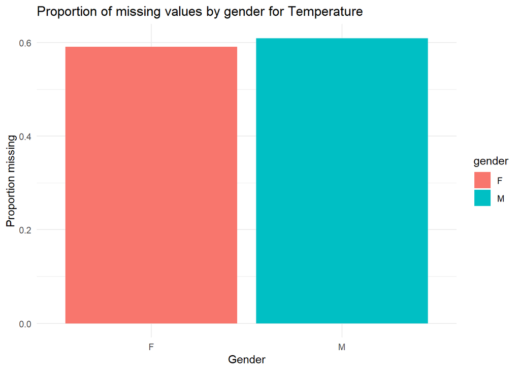

```
##
## Summary table for Glucose..whole.blood.
## # A tibble: 2 × 4
##   gender min_missing max_missing mean_missing
##   <chr>        <dbl>       <dbl>        <dbl>
## 1 F            0.551       0.551        0.551
## 2 M            0.410       0.410        0.410
## [1] "Chi-square test result for Glucose..whole.blood."
##
##  Pearson's Chi-squared test with Yates' continuity correction
##
## data:  chi_sq_variable
## X-squared = 119.69, df = 1, p-value < 2.2e-16
```

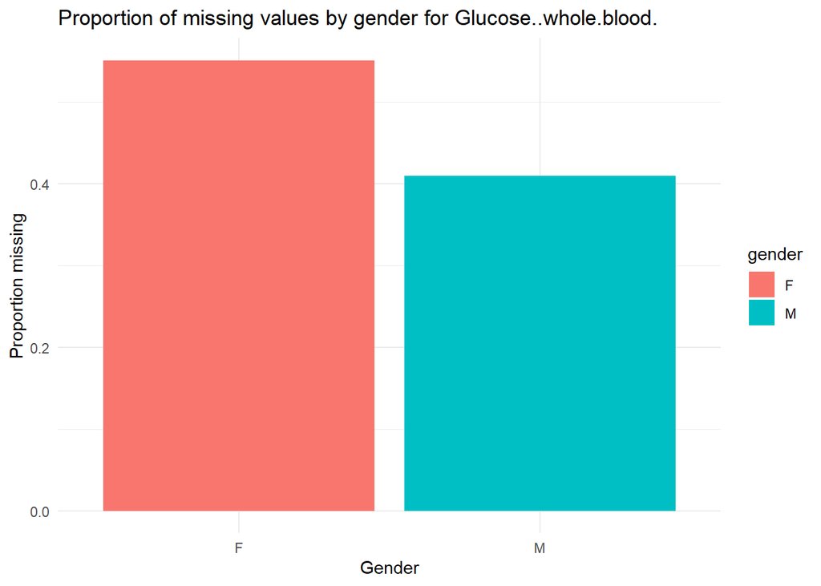

```
##
## Summary table for AvgChloride
## # A tibble: 2 × 4
##   gender min_missing max_missing mean_missing
##   <chr>        <dbl>       <dbl>        <dbl>
## 1 F            0.430       0.430        0.430
## 2 M            0.310       0.310        0.310
## [1] "Chi-square test result for AvgChloride"
##
##  Pearson's Chi-squared test with Yates' continuity correction
##
## data:  chi_sq_variable
## X-squared = 94.036, df = 1, p-value < 2.2e-16
```

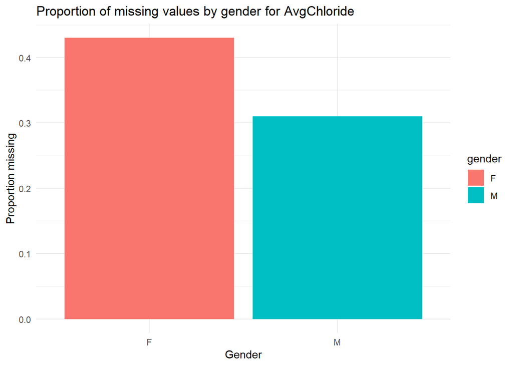

```
##
## Summary table for AvgSodium
## # A tibble: 2 × 4
##   gender min_missing max_missing mean_missing
##   <chr>        <dbl>       <dbl>        <dbl>
## 1 F            0.403       0.403        0.403
## 2 M            0.290       0.290        0.290
## [1] "Chi-square test result for AvgSodium"
##
##  Pearson's Chi-squared test with Yates' continuity correction
##
## data:  chi_sq_variable
## X-squared = 85.388, df = 1, p-value < 2.2e-16
```

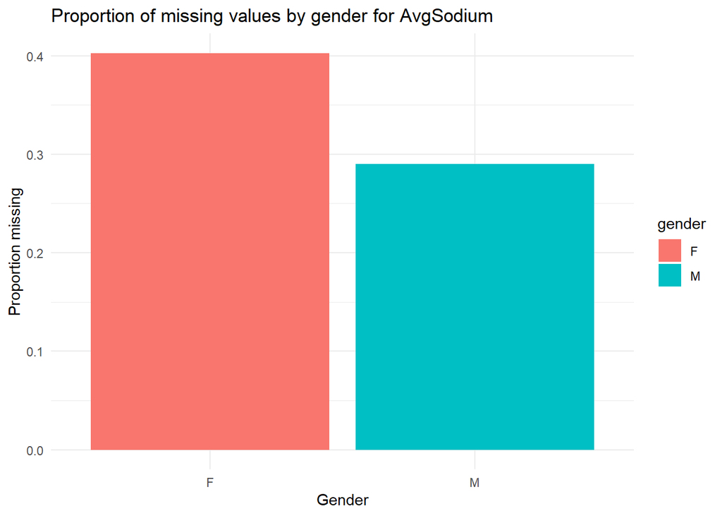

```
##
## Summary table for AvgPotassium
## # A tibble: 2 × 4
##   gender min_missing max_missing mean_missing
##   <chr>        <dbl>       <dbl>        <dbl>
## 1 F            0.283       0.283        0.283
## 2 M            0.191       0.191        0.191
## [1] "Chi-square test result for AvgPotassium"
##
##  Pearson's Chi-squared test with Yates' continuity correction
##
## data:  chi_sq_variable
## X-squared = 71.826, df = 1, p-value < 2.2e-16
```

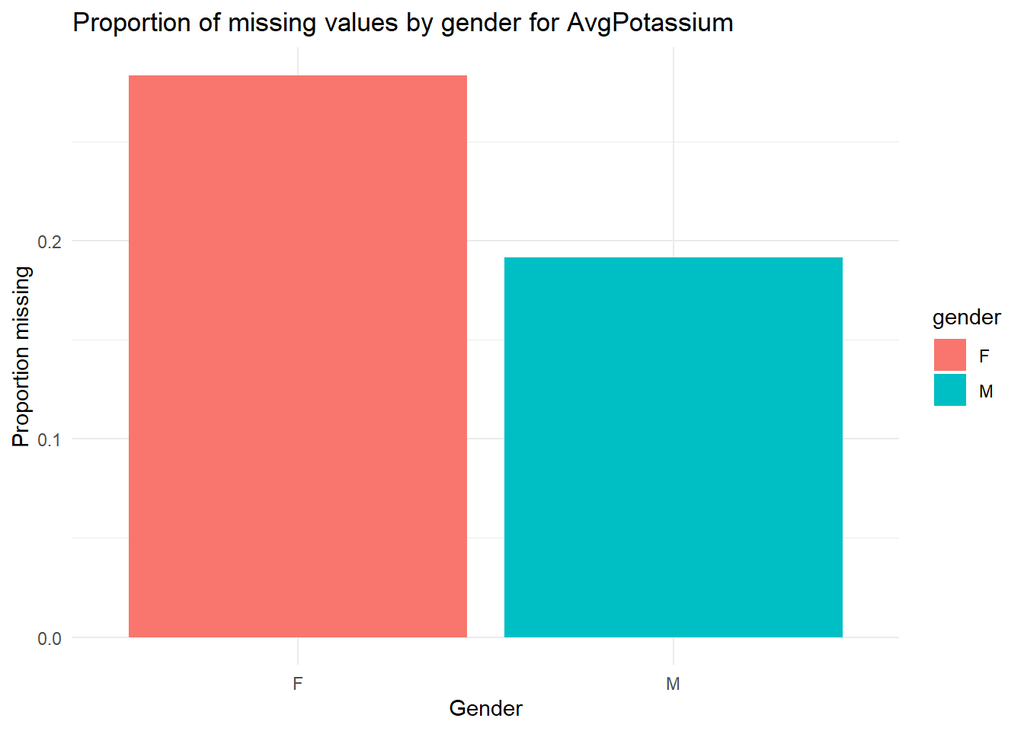

```r
# Loop through each variable
for (variable in variables) {
  # Calculate the proportion of missing values by gender
  missing_summary_variable <- mimic_iv_clean %>%
    group_by(gender) %>%
    summarise(prop_missing = mean(is.na(!!sym(variable))))

  # Summarize the proportions
  summary_table_variable <- missing_summary_variable %>%
    group_by(gender) %>%
    summarise(min_missing = min(prop_missing),
              max_missing = max(prop_missing),
              mean_missing = mean(prop_missing))

  # Print the summary table
  cat("\nSummary table for", variable, "\n")
  print(summary_table_variable)

  # Perform chi-square test
  chi_sq_variable <- table(is.na(mimic_iv_clean[[variable]]), mimic_iv_clean$gender)
  chi_sq_result <- chisq.test(chi_sq_variable)
  print(paste("Chi-square test result for", variable))
  print(chi_sq_result)

  # Visualization
  plot <- ggplot(missing_summary_variable, aes(x = gender, y = prop_missing, fill = gender)) +
    geom_bar(stat = "identity") +
    labs(title = paste("Proportion of missing values by gender for", variable),
         x = "Gender",
         y = "Proportion missing") +
    theme_minimal()
  print(plot)
}
```

**Missingness by Ethnicity**

```
##
## Summary table for Temperature
## # A tibble: 33 × 4
##    ethnicity                     min_missing max_missing mean_missing
##    <chr>                               <dbl>       <dbl>        <dbl>
##  1 AMERICAN INDIAN/ALASKA NATIVE       0.5         0.5          0.5
##  2 ASIAN                               0.627       0.627        0.627
##  3 ASIAN - ASIAN INDIAN                0.824       0.824        0.824
##  4 ASIAN - CHINESE                     0.531       0.531        0.531
##  5 ASIAN - KOREAN                      0.333       0.333        0.333
##  6 ASIAN - SOUTH EAST ASIAN            0.438       0.438        0.438
##  7 BLACK/AFRICAN                       0.647       0.647        0.647
##  8 BLACK/AFRICAN AMERICAN              0.474       0.474        0.474
##  9 BLACK/CAPE VERDEAN                  0.545       0.545        0.545
## 10 BLACK/CARIBBEAN ISLAND              0.533       0.533        0.533
## # ℹ 23 more rows
```

```
## [1] "Chi-square test result for Temperature"
##
##  Pearson's Chi-squared test
##
## data:  chi_sq_variable
## X-squared = 85.386, df = 32, p-value = 9.503e-07
```

```
##
## Summary table for Glucose..whole.blood.
## # A tibble: 33 × 4
##    ethnicity                     min_missing max_missing mean_missing
##    <chr>                               <dbl>       <dbl>        <dbl>
##  1 AMERICAN INDIAN/ALASKA NATIVE       0.8         0.8          0.8
##  2 ASIAN                               0.608       0.608        0.608
##  3 ASIAN - ASIAN INDIAN                0.471       0.471        0.471
##  4 ASIAN - CHINESE                     0.562       0.562        0.562
##  5 ASIAN - KOREAN                      0.667       0.667        0.667
##  6 ASIAN - SOUTH EAST ASIAN            0.438       0.438        0.438
##  7 BLACK/AFRICAN                       0.824       0.824        0.824
##  8 BLACK/AFRICAN AMERICAN              0.547       0.547        0.547
##  9 BLACK/CAPE VERDEAN                  0.591       0.591        0.591
## 10 BLACK/CARIBBEAN ISLAND              0.6         0.6          0.6
## # ℹ 23 more rows
```

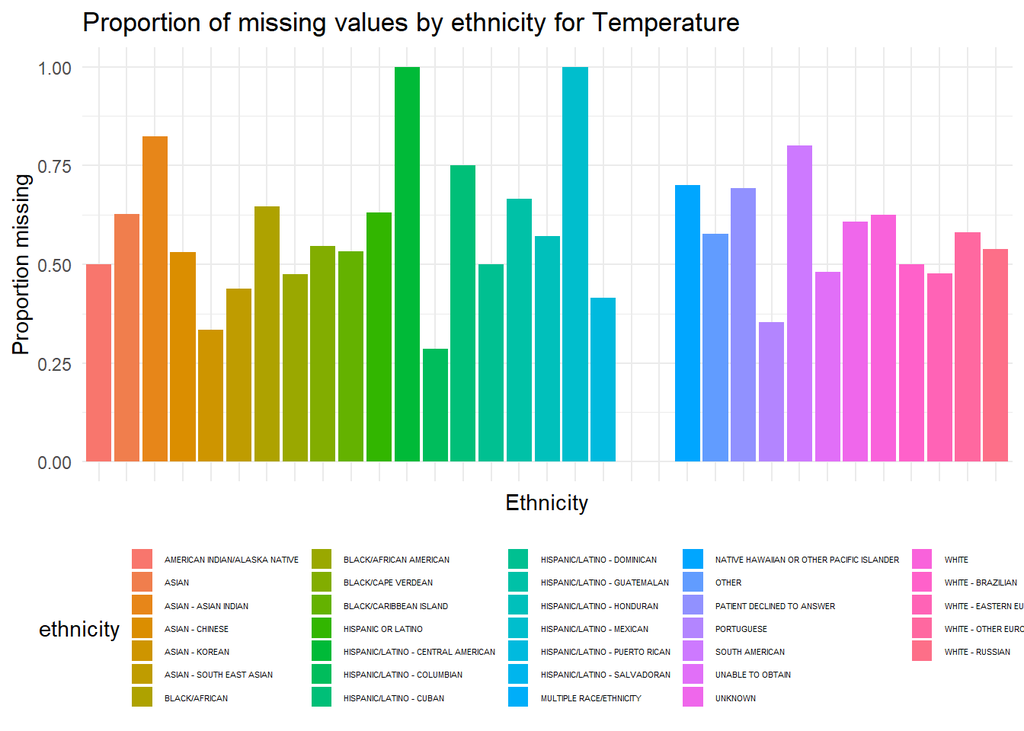

```
## [1] "Chi-square test result for Glucose..whole.blood."
##
##  Pearson's Chi-squared test
##
## data:  chi_sq_variable
## X-squared = 73.935, df = 32, p-value = 3.633e-05
```

```
##
## Summary table for AvgChloride
## # A tibble: 33 × 4
##    ethnicity                     min_missing max_missing mean_missing
##    <chr>                               <dbl>       <dbl>        <dbl>
##  1 AMERICAN INDIAN/ALASKA NATIVE       0.8         0.8          0.8
##  2 ASIAN                               0.510       0.510        0.510
##  3 ASIAN - ASIAN INDIAN                0.471       0.471        0.471
##  4 ASIAN - CHINESE                     0.375       0.375        0.375
##  5 ASIAN - KOREAN                      0.333       0.333        0.333
##  6 ASIAN - SOUTH EAST ASIAN            0.25        0.25         0.25
##  7 BLACK/AFRICAN                       0.471       0.471        0.471
##  8 BLACK/AFRICAN AMERICAN              0.329       0.329        0.329
##  9 BLACK/CAPE VERDEAN                  0.5         0.5          0.5
## 10 BLACK/CARIBBEAN ISLAND              0.467       0.467        0.467
## # ℹ 23 more rows
```

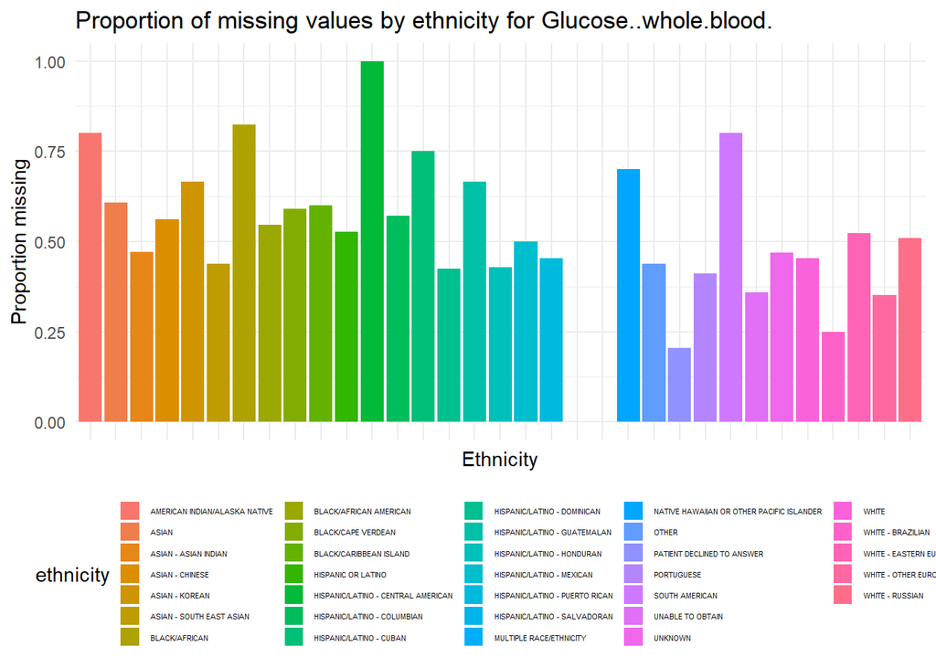

```
## [1] "Chi-square test result for AvgChloride"
##
##  Pearson's Chi-squared test
##
## data:  chi_sq_variable
## X-squared = 74.873, df = 32, p-value = 2.726e-05
```

```
##
## Summary table for AvgSodium
## # A tibble: 33 × 4
##    ethnicity                     min_missing max_missing mean_missing
##    <chr>                               <dbl>       <dbl>        <dbl>
##  1 AMERICAN INDIAN/ALASKA NATIVE       0.8         0.8          0.8
##  2 ASIAN                               0.451       0.451        0.451
##  3 ASIAN - ASIAN INDIAN                0.412       0.412        0.412
##  4 ASIAN - CHINESE                     0.328       0.328        0.328
##  5 ASIAN - KOREAN                      0.333       0.333        0.333
##  6 ASIAN - SOUTH EAST ASIAN            0.312       0.312        0.312
##  7 BLACK/AFRICAN                       0.529       0.529        0.529
##  8 BLACK/AFRICAN AMERICAN              0.290       0.290        0.290
##  9 BLACK/CAPE VERDEAN                  0.5         0.5          0.5
## 10 BLACK/CARIBBEAN ISLAND              0.433       0.433        0.433
## # ℹ 23 more rows
```

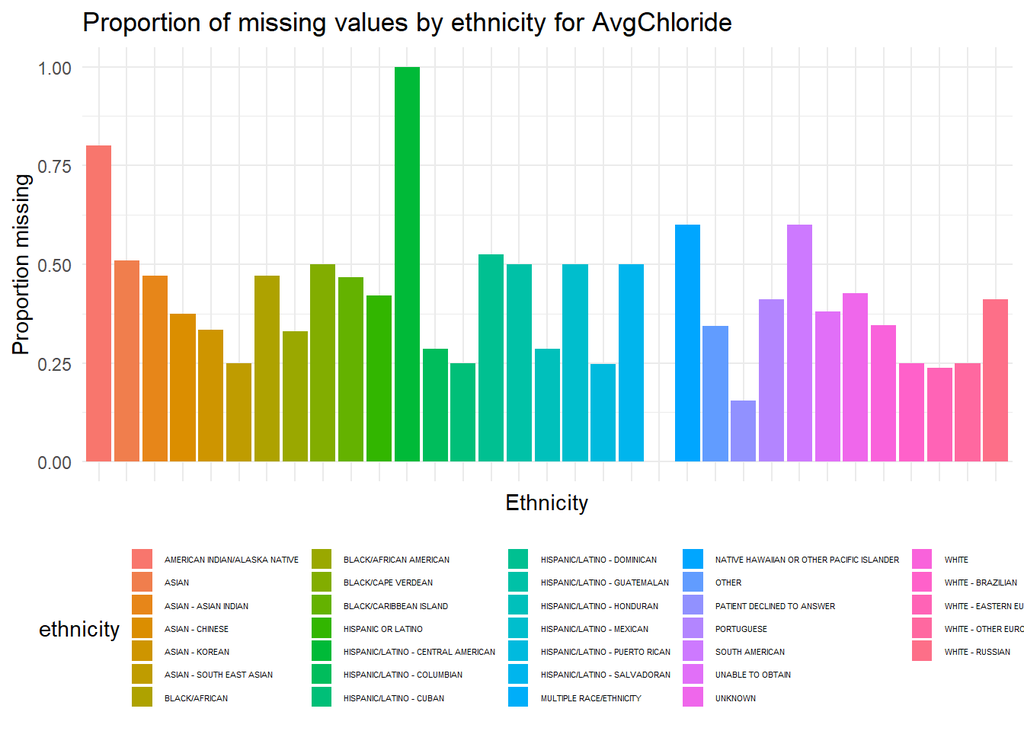

```
## [1] "Chi-square test result for AvgSodium"
##
##  Pearson's Chi-squared test
##
## data:  chi_sq_variable
## X-squared = 69.65, df = 32, p-value = 0.0001313
```

```
##
## Summary table for AvgPotassium
## # A tibble: 33 × 4
##    ethnicity                     min_missing max_missing mean_missing
##    <chr>                               <dbl>       <dbl>        <dbl>
##  1 AMERICAN INDIAN/ALASKA NATIVE       0.6         0.6          0.6
##  2 ASIAN                               0.333       0.333        0.333
##  3 ASIAN - ASIAN INDIAN                0.353       0.353        0.353
##  4 ASIAN - CHINESE                     0.156       0.156        0.156
##  5 ASIAN - KOREAN                      0           0            0
##  6 ASIAN - SOUTH EAST ASIAN            0.25        0.25         0.25
##  7 BLACK/AFRICAN                       0.294       0.294        0.294
##  8 BLACK/AFRICAN AMERICAN              0.143       0.143        0.143
##  9 BLACK/CAPE VERDEAN                  0.273       0.273        0.273
## 10 BLACK/CARIBBEAN ISLAND              0.233       0.233        0.233
## # ℹ 23 more rows
```

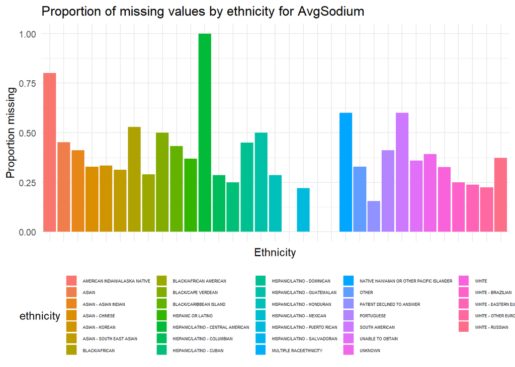

```
## [1] "Chi-square test result for AvgPotassium"
##
##  Pearson's Chi-squared test
##
## data:  chi_sq_variable
## X-squared = 90.527, df = 32, p-value = 1.7e-07
```

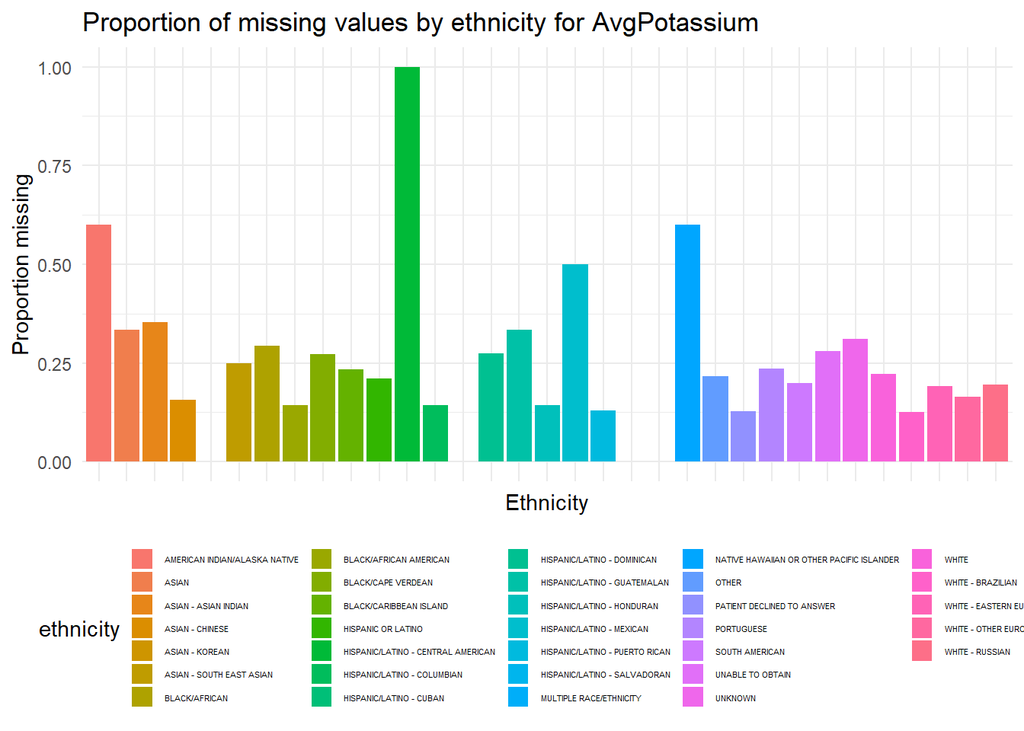

```r
# Loop through each variable
for (variable in variables) {
  # Calculate the proportion of missing values by ethnicity
  missing_summary_variable <- mimic_iv_clean %>%
    group_by(ethnicity) %>%
    summarise(prop_missing = mean(is.na(!!sym(variable))))

  # Summarize the proportions
  summary_table_variable <- missing_summary_variable %>%
    group_by(ethnicity) %>%
    summarise(min_missing = min(prop_missing),
              max_missing = max(prop_missing),
              mean_missing = mean(prop_missing))

  # Print the summary table
  cat("\nSummary table for", variable, "\n")
  print(summary_table_variable)

  # Perform chi-square test
  chi_sq_variable <- table(is.na(mimic_iv_clean[[variable]]), mimic_iv_clean$ethnicity)
  chi_sq_result <- chisq.test(chi_sq_variable)
  print(paste("Chi-square test result for", variable))
  print(chi_sq_result)

  # Visualization
  plot <- ggplot(missing_summary_variable, aes(x = ethnicity, y = prop_missing, fill = ethnicity)) +
    geom_bar(stat = "identity") +
    labs(title = paste("Proportion of missing values by ethnicity for", variable),
         x = "Ethnicity",
         y = "Proportion missing") +
    theme_minimal() +
    theme(axis.text.x = element_blank(),
          legend.position = "bottom",
          legend.key.width = unit(0.4, "cm"),
          legend.key.height = unit(0.4, "cm"),
          legend.text = element_text(size = unit(4, "cm")))

  print(plot)
}
```

**Missingness by Mortality**

```
##
## Summary table for Temperature
## # A tibble: 2 × 4
##   mortality min_missing max_missing mean_missing
##       <int>       <dbl>       <dbl>        <dbl>
## 1         0       0.658       0.658        0.658
## 2         1       0.291       0.291        0.291
## [1] "Chi-square test result for Temperature"
##
##  Pearson's Chi-squared test with Yates' continuity correction
##
## data:  chi_sq_variable
## X-squared = 460.22, df = 1, p-value < 2.2e-16
```

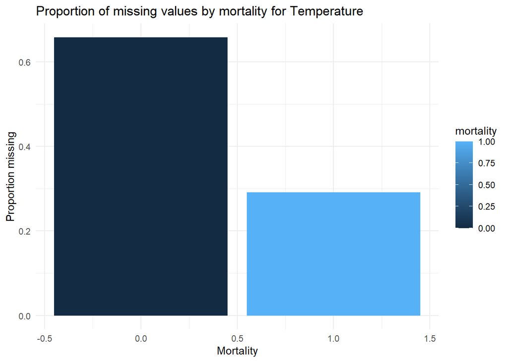

```
##
## Summary table for Glucose..whole.blood.
## # A tibble: 2 × 4
##   mortality min_missing max_missing mean_missing
##       <int>       <dbl>       <dbl>        <dbl>
## 1         0       0.459       0.459        0.459
## 2         1       0.487       0.487        0.487
## [1] "Chi-square test result for Glucose..whole.blood."
##
##  Pearson's Chi-squared test with Yates' continuity correction
##
## data:  chi_sq_variable
## X-squared = 2.5409, df = 1, p-value = 0.1109
```

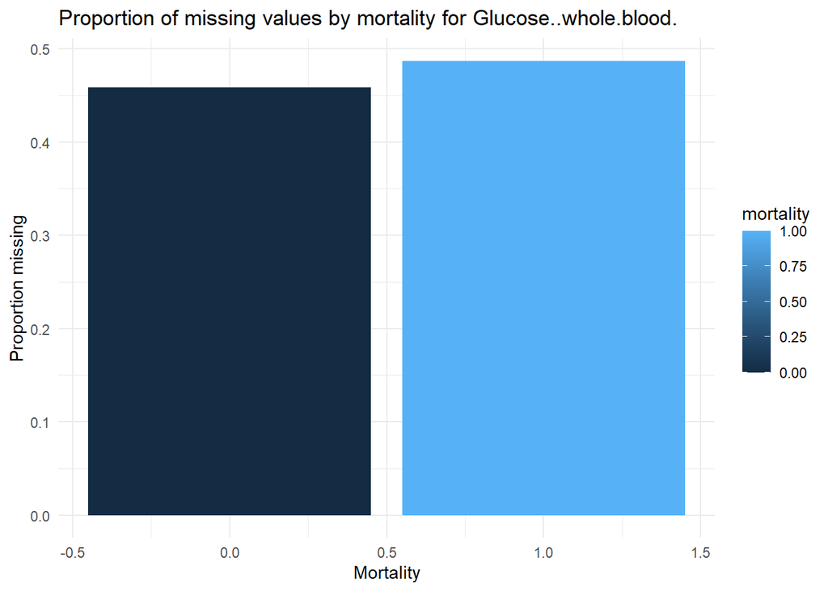

```
##
## Summary table for AvgChloride
## # A tibble: 2 × 4
##   mortality min_missing max_missing mean_missing
##       <int>       <dbl>       <dbl>        <dbl>
## 1         0       0.345       0.345        0.345
## 2         1       0.412       0.412        0.412
## [1] "Chi-square test result for AvgChloride"
##
##  Pearson's Chi-squared test with Yates' continuity correction
##
## data:  chi_sq_variable
## X-squared = 15.682, df = 1, p-value = 7.492e-05
```

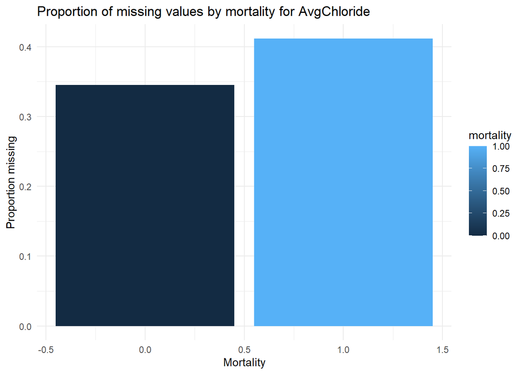

```
##
## Summary table for AvgSodium
## # A tibble: 2 × 4
##   mortality min_missing max_missing mean_missing
##       <int>       <dbl>       <dbl>        <dbl>
## 1         0       0.325       0.325        0.325
## 2         1       0.373       0.373        0.373
## [1] "Chi-square test result for AvgSodium"
##
##  Pearson's Chi-squared test with Yates' continuity correction
##
## data:  chi_sq_variable
## X-squared = 8.1352, df = 1, p-value = 0.004341
```

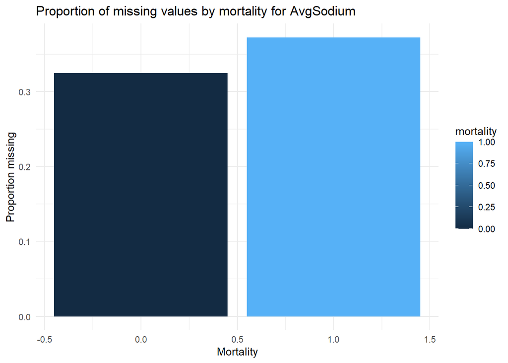

```
##
## Summary table for AvgPotassium
## # A tibble: 2 × 4
##   mortality min_missing max_missing mean_missing
##       <int>       <dbl>       <dbl>        <dbl>
## 1         0       0.231       0.231        0.231
## 2         1       0.196       0.196        0.196
## [1] "Chi-square test result for AvgPotassium"
##
##  Pearson's Chi-squared test with Yates' continuity correction
##
## data:  chi_sq_variable
## X-squared = 5.6366, df = 1, p-value = 0.01759
```

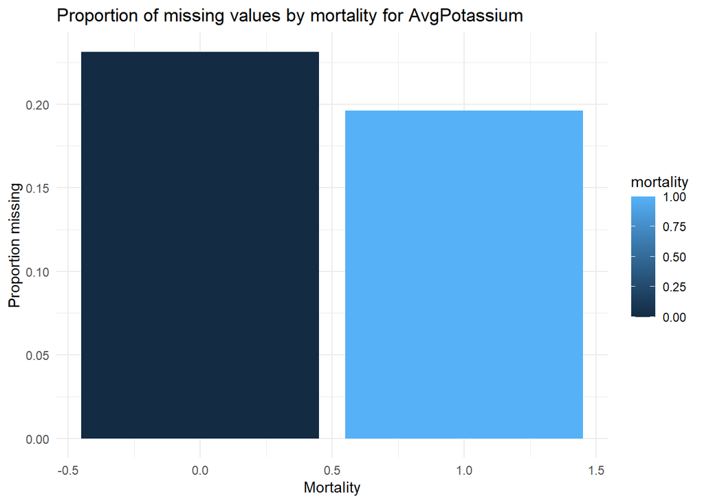

```r
# Loop through each variable
for (variable in variables) {
  # Calculate the proportion of missing values by mortality
  missing_summary_variable <- mimic_iv_clean %>%
    group_by(mortality) %>%
    summarise(prop_missing = mean(is.na(!!sym(variable))))

  # Summarize the proportions
  summary_table_variable <- missing_summary_variable %>%
    group_by(mortality) %>%
    summarise(min_missing = min(prop_missing),
              max_missing = max(prop_missing),
              mean_missing = mean(prop_missing))

  # Print the summary table
  cat("\nSummary table for", variable, "\n")
  print(summary_table_variable)

  # Perform chi-square test
  chi_sq_variable <- table(is.na(mimic_iv_clean[[variable]]), mimic_iv_clean$mortality)
  chi_sq_result <- chisq.test(chi_sq_variable)
  print(paste("Chi-square test result for", variable))
  print(chi_sq_result)

  # Visualization
  plot <- ggplot(missing_summary_variable, aes(x = mortality, y = prop_missing, fill = mortality)) +
    geom_bar(stat = "identity") +
    labs(title = paste("Proportion of missing values by mortality for", variable),
         x = "Mortality",
         y = "Proportion missing") +
    theme_minimal()
  print(plot)
}
```